# Datenanalyse mit Python

**Wintersemester 2024/2025**  
**durchgeführt von Simone Arnold und Maik Poetzsch**

# Datenanalyse

In diesem Kapitel werden die Grundlagen der Datenanalyse vorgestellt. Dazu gehören die drei Schwerpunkte:

- Daten visualisieren
- Daten numerisch verarbeiten
- Daten modellieren

Die folgenden Unterkapitel geben einen Einblick in die einzelnen Schwerpunkte.

# Visualisierung

Die Visualisierung von Daten gehört zu den wichtigsten Werkzeugen bei der Datenanalyse. Menschen können mit ihrer visuellen Wahrnehmung schnell Strukturen und Zusammenhänge erkennen, vorausgesetzt die Daten sind entsprechend dargestellt.

In diesem Kapitel wird das Modul matplotlib vorgestellt, welches für die graphische Aufbereitung von Daten häufig eingesetzt wird. Neben einer grundlegenden Einführung in den Aufbau von Graphiken, werden anhand von eindimensionalen Daten einige Darstellungsfunktionen demonstriert. Zusätzlich werden die Beschriftung, Farbwahl als auch zusätzliche Anpassungsmöglichkeiten von Graphiken zusammengefasst.

# matplotlib-Modul

Eine der populärsten Module zur Visualisierung ist [matplotlib](https://matplotlib.org/). Eine Übersicht der Visualisierungsmöglichkeiten ist in der [Galerie](https://matplotlib.org/gallery/index.html) gegeben.

## Laden des Moduls

Das matplotlib-Modul kann wie gewohnt mit dem `import` Schlüsselwort eingebunden werden. Dabei wird insbesondere das [pyplot-Untermodul](https://matplotlib.org/3.2.1/api/_as_gen/matplotlib.pyplot.html) im Weiteren benötigt. Als Konvention hat sich das Kürzel `plt` für dieses Modul etabliert.

```python
import matplotlib.pyplot as plt
```

In den nachfolgenden Teilen des Skripts ist mit der Abkürzung `plt` immer `matplotlib.pyplot` gemeint.

## Aufbau einer Graphik

Folgende Schritte sind zur Erstellung einer Graphik nötig:

1. (optional) Definition der Rahmenbedingungen der Graphik, z.B. Größe
2. Definition der Graphikelemente
3. Ausgabe auf dem Bildschirm oder in eine Datei

Anhand des folgenden Beispiels werden die einzelnen Schritte erläutert. Aufgrund der Interaktion zwischen Jupyter und matplotlib, empfiehlt es sich, alle Schritte in einer einzelnen Zelle auszuführen.

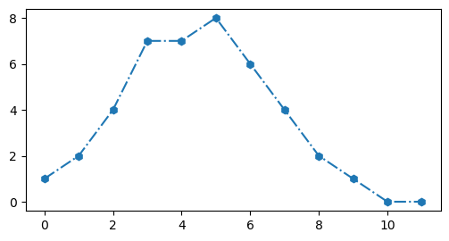

```python
# (optionale) Zusatzinformationen für die Graphik
plt.figure(figsize=(6,3), dpi=100)

# Definition der Graphikelemente
werte = [1, 2, 4, 7, 7, 8, 6, 4, 2, 1, 0, 0]
plt.plot(werte, '-.h')

# Speichern in Datei, z.B. als PDF
plt.savefig('einfache_graphik.pdf')

# Ausgabe der Graphik, nicht notwendig in Jupyter
# plt.show()
```

Der erste Schritt ist optional und ermöglicht, unter anderem, das Festlegen der Graphikgröße und -auflösung. Neben der `figure`-Methode stehen weitere Methoden bereit, welche beispielsweise erlauben, mehrere Plots neben- und untereinander darzustellen.

Um mit der `figure`-Methode die Bildgröße anzupassen, kann das Argument `figsize` verwendet werden, hier wird die Bildgröße als 2er-Tupel in Zoll angegeben. Die Auflösung der Graphik wird in DPI (dots per inch) über das Argument `dpi` definiert.

Ein notwendiger Schritt ist der Aufbau der Elemente der Graphik. Hier werden beispielsweise Datenpunkte definiert, Beschriftungen angegeben oder eine Legende erzeugt. Als einfaches Beispiel wird oben eine Werteliste (`werte`) als mit Linien verbundene Punkte mit der `plot`-Methode dargestellt.

In allgemeinen Python-Skripten ist das explizite Anzeigen der Graphik mit der `show`-Methode notwendig. In Jupyter erfolgt dies automatisch am Ende der Ausführung einer Zelle. Neben der Ausgabe auf dem Bildschirm, kann eine Graphik auch als Datei gespeichert werden. Dazu wird die `savefig`-Methode verwendet, welche als Argument den Dateinamen bekommt. Das Bildformat wird anhand der Dateiendung automatisch ermittelt. Grundsätzlich empfiehlt es sich Vektorformate wie PDF oder SVG zu verwenden. Die im Beispiel erstellte Graphik ist als PDF-Datei abgespeichert.

Fast alle obigen Methoden geben als Rückgabewerte Objekte zurück. Diese werden im Rahmen dieser Veranstaltung meist nicht benötigt und somit einfach ignoriert. Jupyter gibt grundsätzlich den Rückgabewert des letzten Ausdrucks zurück. Diese Ausgabe kann mit einem `;` nach dem Ausdruck unterdrückt werden.

# Eindimensionale Daten

```python
import matplotlib.pyplot as plt
```

## Liniendiagramme

Eine der am häufigsten verwendeten Darstellungsformen sind Liniendiagramme. Diese werden mit der Methode `plt.plot` erstellt. Eine ausführliche Dokumentation finden Sie [hier](https://matplotlib.org/3.2.1/api/_as_gen/matplotlib.pyplot.plot.html#matplotlib.pyplot.plot). Im Folgenden werden die Grundfunktionen von `plt.plot` kurz zusammengefasst.

Grundsätzlich werden zwei Listen übergeben, wobei die erste die x-Werte und die zweite die y-Werte der abzubildenden Daten enthält. Wird nur eine Liste übergeben, so werden diese als y-Werte interpretiert und gegen ihren Index aufgetragen.

```python
werte = [1, 2, 4, 7, 7, 8, 6, 4, 2, 1, 0, 0]
```

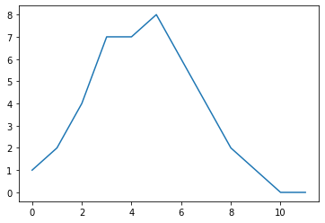

```python
plt.plot(werte);
```

```python
x = [-3.5, -3, -2, -1.5, -1.0, 2.2, 2.5, 3.5]
y = []
for cx in x:
    y.append(cx**3)
```

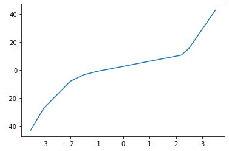

```python
plt.plot(x, y);
```

Die Linienart kann mit dem Argument `linestyle` bzw. in kurz `ls` angepasst werden:

[output not shown]

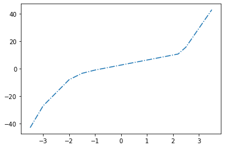

```python
plt.plot(x, y, ls='-.');
```

Darüber hinaus können die Punkte, welche durch die Linien verbunden werden, als Marker dargestellt werden. Dies erfolgt über das `marker` Argument. Eine Auswahl ist in folgender Tabelle gegeben.

| `marker` | Punktedarstellung |
| --- | --- |
| `.` | Punkt |
| `o` | Kreis |
| `s` | Quadrat |
| `+` | Pluszeichen |
| `x` | x-Zeichen |
| `D` | Diamantform |

Die Größe der Marker kann mit dem Argument `markersize` gesetzt werden.

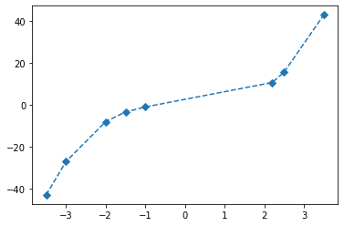

```python
plt.plot(x, y, ls='--', marker='D');
```

Die Linienstärke kann mit dem Argument `linewidth` bzw. `lw` angegeben werden.

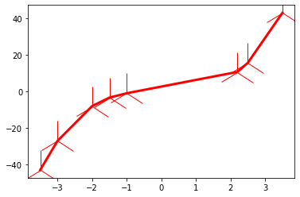

```python
plt.plot(x, y, ls='-', lw=3, marker='2', markersize=50 , color ='r');
```

## Punktwolken

Sollen Punktdaten, d.h. Punkte ohne eine verbindende Linie, dargestellt werden, kann dazu die [`plt.scatter` Methode](https://matplotlib.org/3.2.1/api/_as_gen/matplotlib.pyplot.scatter.html#matplotlib.pyplot.scatter) genutzt werden. Diese bekommt immer zwei Argumente, die x- und y-Positionen der Punkte. Darüber hinaus ist es hier möglich, die Größe und Farbe der Punkte anzugeben.

```python
import math as m

# das random-Modul kann z.B. Zufallszahlen erzeugen
import random
```

```python
n = 1000
px = []
py = []
pr = []
for i in range(n):
    cx = m.sin(i)
    cy = m.cos(i)
    cr = random.random() # m.exp(-i*i/10000)
    px.append(cr * cx)
    py.append(cr * cy)
    pr.append(cr*20)
```

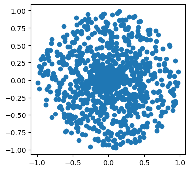

```python
plt.figure(figsize=(4,4), dpi=100)
plt.scatter(px, py);
```

Das Argument `s` erlaubt die Anpassung der Größe der Punkte. Wird nur ein einziger Wert angegeben, gilt dieser für jeden Punkt, alternativ kann mit Hilfe einer Liste für jeden Punkt individuell eine Größe festgelegt werden. Die Liste muss entsprechend genauso viele Elemente beinhalten wie Datenpunkte vorhanden sind.

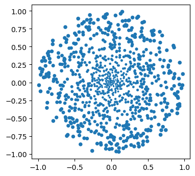

```python
plt.figure(figsize=(4,4), dpi=100)
plt.scatter(px, py, s=pr);
```

## Balkendiagramme

Mit der [Methode `plt.bar`](https://matplotlib.org/3.2.1/api/_as_gen/matplotlib.pyplot.bar.html#matplotlib.pyplot.bar) werden Balkendiagramme erstellt. Sie benötigt mindesten zwei Argumente: die Position der Balken und deren Höhe.

```python
bx = list(range(5,15))
bh = []
for cx in bx:
    bh.append(cx**4/10000)
```

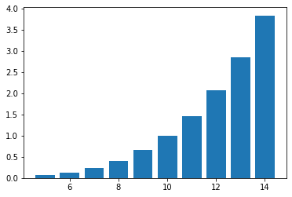

```python
plt.bar(bx, bh);
```

# Beschriftung

Im matplotlib-Modul stehen viele Möglichkeiten zur Beschriftung der einzelnen Graphikelemente zur Verfügung. In diesem Kapitel wird eine kleine Auswahl präsentiert.

```python
import matplotlib.pyplot as plt
```

## Achsenbeschriftung

Die Achsen können mit den Methoden `plt.xlabel` bzw. `plt.ylabel` beschriftet werden.

```python
x = []
y2 = []
y3 = []
for i in range(20):
    cx = -5 + i*0.5
    x.append( cx )
    y2.append( 8 - cx**2 )
    y3.append( 0.2*cx**3 - 2*cx )
```

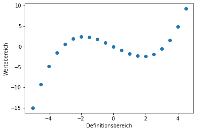

```python
plt.scatter(x, y3)

plt.xlabel('Definitionsbereich')
plt.ylabel('Wertebereich');
```

## Titel

Über der Graphik kann eine Überschrift plaziert werden. Dies erfolgt mit der `plt.title`-Methode.

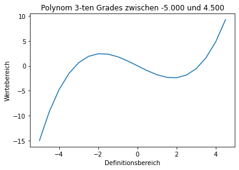

```python
plt.plot(x, y3)

plt.xlabel('Definitionsbereich')
plt.ylabel('Wertebereich')

titel = f"Polynom 3-ten Grades zwischen {min(x):.3f} und {max(x):.3f}"
plt.title(titel);
```

## Legende

Werden mehrere Datensätze gleichzeitig dargestellt, so sollte eine Legende verwendet werden, um die einzelnen Daten zu beschreiben. Dazu muss beim Erstellen der Graphikelemente das Argument `label` mit einer entsprechenden Zeichenkette angegeben werden. Sind alle Elemente erstellt, wird mit der Methode `plt.legend` eine Legende generiert.

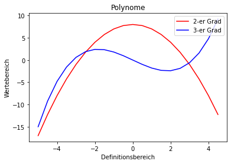

```python
plt.plot(x, y2, label='2-er Grad', color = 'r')
plt.plot(x, y3, label='3-er Grad', color = 'b')

plt.legend(loc = 'upper right')

plt.xlabel('Definitionsbereich')
plt.ylabel('Wertebereich')

plt.title("Polynome");
```

## Gitter

Die Methode `plt.grid` erweitert eine Graphik um ein Gitter, welches ein genaueres Ablesen bzw. Vergleichen von Werten ermöglicht.

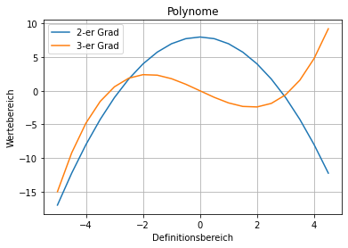

```python
plt.plot(x, y2, label='2-er Grad')
plt.plot(x, y3, label='3-er Grad')

plt.legend()

plt.xlabel('Definitionsbereich')
plt.ylabel('Wertebereich')

plt.title("Polynome")

plt.grid();
```

## Hilfslinien

Linien, welche parallel zu den Achsen verlaufen und sich über den gesamten Graphikbereich erstrecken sollen, können mit den Methoden `plt.axhline` bzw. `plt.axvline` erstellt werden.

Im folgenden Beispiel wird zur besseren Veranschaulichung die Wahl einer Darstellungsfarbe vorgegriffen.

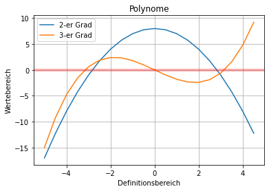

```python
plt.plot(x, y2, label='2-er Grad')
plt.plot(x, y3, label='3-er Grad')

plt.axhline(y=0, color='red', lw=4, alpha=0.3)

plt.legend()

plt.xlabel('Definitionsbereich')
plt.ylabel('Wertebereich')

plt.title("Polynome")

plt.grid();
```

# Skalierung

Die Wahl der richtigen Skalierung, d.h. des Darstellungsbereichs und der Darstellungsbasis, ist beim Vergleich von Daten wichtig.

```python
import matplotlib.pyplot as plt
```

```python
# Beispieldatensätze

x = []
y0 = []
y1 = []
for i in range(20):
    cx = i * 0.5
    x.append( cx )
    y0.append( 5*cx )
    y1.append( cx**3 * 1e-1 )
```

## Darstellungsbereich

Der Darstellungsbereich kann mit den Methoden `plt.xlim` bzw. `plt.ylim` gewählt werden. Grundsätzlich wählt matplotlib den Bereich so aus, dass alle Daten darin abgebildet werden können. Mit Hilfe der beiden Funktionen können diese Bereiche manuell festlegen.

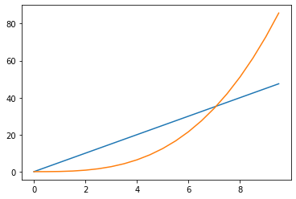

```python
# Vergleichsgraphik
plt.plot(x, y0)
plt.plot(x, y1);
```

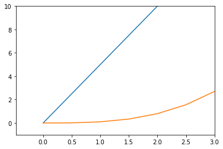

```python
# Beispielplots
plt.plot(x, y0)
plt.plot(x, y1)

# Definition des darzustellenden Bereichs
plt.xlim(right=3)
plt.ylim([-1,10]);

plt.savefig('bild_1.png', dpi=200)
```

## Basis

Anstelle einer linearen Darstellung der Daten können für Graphiken z.B. logarithmische Achsen gewählt werden. Hierzu werden die Methoden `plt.xscale` bzw. `plt.yscale` verwendet. Um die entsprechende Achse logarithmisch darzustellen, wird das Argument `'log'` übergeben.

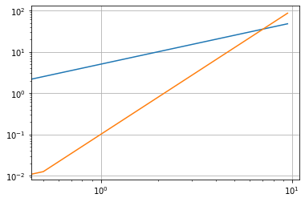

```python
plt.plot(x, y0)
plt.plot(x, y1)

plt.xscale('log')
plt.yscale('log')

plt.grid()
```

# Aufgaben Teil 1

### _Aufgabe 1.1: Plotten von Funktionen_

Plotten Sie die Quadratfunktion $\sf f(x) = x^2$ und ihre analytische Ableitung für Werte im Bereich $\sf x \in [-9,9]$. Dabei sollte $\sf f(x)$ mit Punkten und durchgezogener Linie in blauer Farbe und die Ableitung als gestrichelte Linie in roter Farbe dargestellt sein. Die x-Achse des gezeichneten Koordinatensystems soll Werte von -10 bis 10 und die y-Achse von -20 bis 100 aufgetragen haben. Weiterhin sind beide Funktionen mittels Legende zu beschriften und Achsenbeschriftung, ein Graphiktitel und ein Gitternetz einzufügen. Der finale Plot soll als Bilddatei abgespeichert werden.

# Farben

Für die meisten Bildelemente kann eine Farbe angegeben werden. Damit lassen sich verschiedene Datensätze voneinander unterscheiden.

```python
import matplotlib.pyplot as plt
```

## Farbnamen

Soll explizit eine bestimmte Farbe verwendet werden, so ist es am einfachsten die vordefinierten Farbnamen, siehe [Beispiel](https://matplotlib.org/3.2.1/gallery/color/named_colors.html#sphx-glr-gallery-color-named-colors-py), zu verwenden. In der `plt.plot`-Methode geschieht dies über das `color`-Argument.

```python
x = []
y0 = []
y1 = []
y2 = []
y3 = []
for i in range(20):
    cx = -5 + i*0.5
    x.append( cx )
    y0.append( -2 )
    y1.append( cx )
    y2.append( 8 - cx**2 )
    y3.append( 0.2*cx**3 - 2*cx )
```

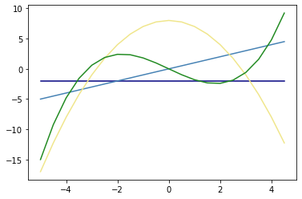

```python
plt.plot(x, y0, color='navy')
plt.plot(x, y1, color='steelblue')
plt.plot(x, y2, color='khaki')
plt.plot(x, y3, color='forestgreen');
```

Werden nicht explizit Farben vorgegeben, wird ein vordefiniertes Farbtableau verwendet.

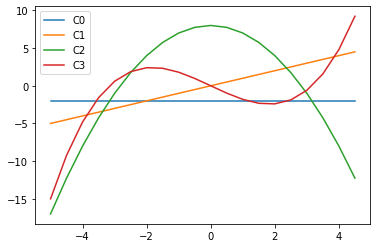

```python
plt.plot(x, y0, label='C0')
plt.plot(x, y1, label='C1')
plt.plot(x, y2, label='C2')
plt.plot(x, y3, label='C3')
plt.legend();
```

Auf diese Farbsequenz kann über die Zeichenkette `CN` zugegriffen werden, wobei das `N` den Index angibt. So ist beispielsweise `C2` die dritte Farbe in dieser Sequenz.

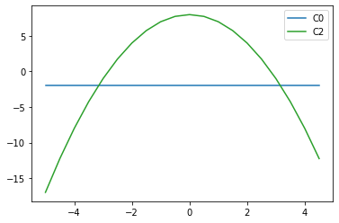

```python
plt.plot(x, y0, color='C0', label='C0')
plt.plot(x, y2, color='C2', label='C2')
plt.legend();
```

## Farbpaletten

Für kontinuierliche Farbverläufe werden Farbpaletten verwendet. Wie in [diesem Beispiel](https://matplotlib.org/3.2.1/gallery/color/colormap_reference.html#sphx-glr-gallery-color-colormap-reference-py) gezeigt, stehen viele Paletten zur auswahl.

Bei Punktwolken kann die Farbe jedes Punktes definiert werden. Dies kann über einen Wert erfolgen, welcher mit einer Farbpalette in eine Farbe übersetzt wird. Zum Ablesen des zugehörigen Werts, kann eine Farbskala mit der `plt.colorbar`-Methode eingeblendet werden.

```python
import math as m
import random
```

```python
n = 1000
px = []
py = []
pr = []
for i in range(n):
    cx = m.sin(i)
    cy = m.cos(i)
    cr = random.random() # m.exp(-i*i/10000)
    px.append(cr * cx)
    py.append(cr * cy)
    pr.append(cr*20)
```

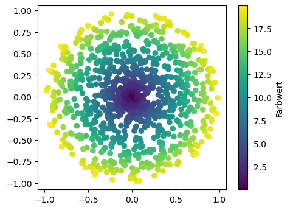

```python
plt.figure(figsize=(5,4), dpi=100)
plt.scatter(px, py, c=pr)
plt.colorbar(label='Farbwert');
```

Die verwendete Farbpalette kann mit dem `cmap`-Argument definiert werden.

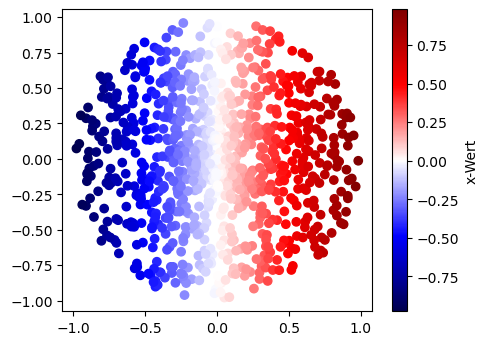

```python
plt.figure(figsize=(5,4), dpi=100)
plt.scatter(px, py, c=px, cmap='seismic')
plt.colorbar(label='x-Wert');
```

## Transparenz

Neben dem Farbwert kann in vielen Fällen auch die Transparenz angegeben werden. Sie nimmt dabei Werte zwischen 0 und 1 an, wobei 0 (0%) einer komplett durchsichtigen Darstellung und 1 (100%) einer undurchsichtigen entspricht. Die Transparenz wird über das `alpha`-Argument übergeben.

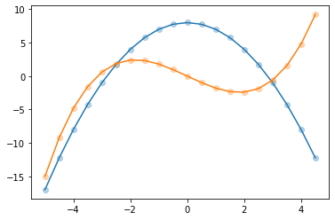

```python
plt.plot(x, y2, color='C0')
plt.plot(x, y2, color='C0', ls='', marker='o', alpha=0.3)

plt.plot(x, y3, color='C1')
plt.plot(x, y3, color='C1', ls='', marker='o', alpha=0.3);
```

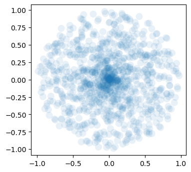

```python
plt.figure(figsize=(4,4), dpi=100)
plt.scatter(px, py, s=100, alpha=0.1, edgecolor='None');
```

# 2D Daten

```python
import matplotlib.pyplot as plt
```

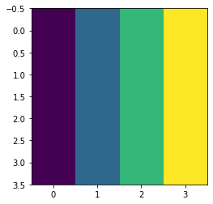

```python
data = []
line = [1, 2, 3, 4]

for i in range(4):
    data.append(line)

plt.imshow(data)
plt.show()
```

# Aufgaben Teil 2

### _Aufgabe 2.1: Plotten von Funktionen_

Diese Aufgabe kombiniert das Auslesen von Daten aus einer Datei mit einer graphischen Ausgabe.

In der Datei niederschlag_rom.txt finden Sie die Regenstatistik von Rom gemittelt für jeden Monat über ein Zeitintervall von 1782 bis 1970. Die ersten Zeilen der Datei sind Kommentarzeilen, die die Randbedingungen und den Aufbau der Messdatei beschreiben. Schreiben Sie ein Programm, das die Messdaten mit Legende graphisch darstellt. In dieser Aufgabe soll die x-Achse eine besondere Beschriftung bekommen. Dabei sollen die Namen der Monate verwendet werden.

### Lösungshinweis

Die Beschriftung der Skala einer Achse, z.B. der x-Achse, kann mit der Funktion `xticks` angepasst werden.

# Aufgaben Teil 3

Ein Energieunternehmen möchte die elektrische Leistung und Wärmeleistung eines Haushalts über 24 Stunden erfassen. Erstellen Sie ein Balkendiagramm, das die Leistungsanforderungen sowohl für elektrische als auch für thermische Energie darstellt.

1. Nutzen Sie die Daten:
   - Stunden des Tages: 1 bis 24
   - Elektrische Leistung in kW: `[30,30,30,30,30,40,50,60,70,80,80,80,50,50,50,60,40,40,30,30,30,30,30,30]`
   - Wärmeleistung in kW: `[60,60,60,60,60,90,90,90,90,90,90,90,90,90,90,90,90,60,60,60,60,60,60,60]`
2. Fügen Sie Achsenbeschriftungen, eine Legende und ein Gitter hinzu. Achten Sie darauf, dass die Balken der elektrischen und der thermischen Leistung so dargestellt werden, dass beide zu erkennen sind.